# Assignment

T.R. Madirawala - AS2016431

6/30/2020

# **Introduction**

COVID-19 pandemic is a world wide pandemic that affected nearly 213 countries. The country Chile is one of the top 58 countries that have been affected by this virus. Chile is situated at Southern South America bordering the South Pasific Ocean.

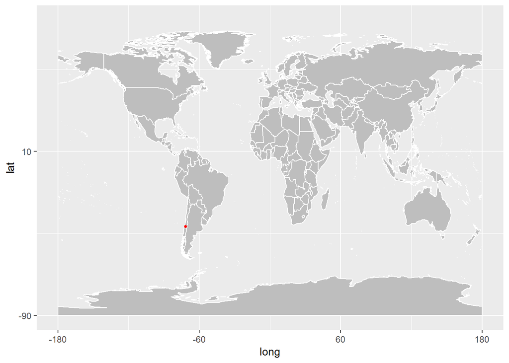

Figure 01- Visualisation of Chile

### Climate Condition

Climate of Chile comprise of wide range of weather conditions through out the year. The teperature varies between 30 degree celcius to even below 0 degree celcius.

### Lockdown Status

No national lockdown has been established in Chile, as in neighbouring Argentina and Peru, but only in some communes and urban areas. On 16 May 2020, the whole city of Santiago was put under mandatory quarantine ( three-week shutdown) due to an increase of cases; similar situation was extended to Valparaíso-Viña del Mar, Antofagasta, Arica and Iquique the following month.

### Actions taken by the government

The Chilean Government has implemented a series of measures to protect its population and strengthen the hospital network across the country. Besides, President Sebastian Piñera has made important announcements in the economic field, in order to help those citizens particularly affected by the health emergency and face the economic consequences of the pandemic. For the protection of citizens the government implimented actions like declaration of state of catastrophe, quarantine, compulsory use of masks in both public and private transportation etc. To strengthening the hospital network created an integral health system, creat special funds, increased number of beds available in the country etc. Introduced three packagers to strengthen the country’s economy.

# **Exploratory Data Analysis**

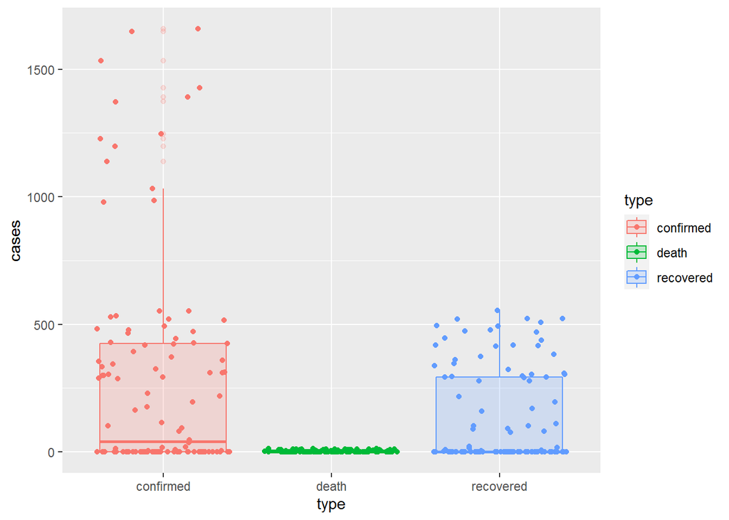

Figure 02- Chile: Boxplot of Covid-19 Cases

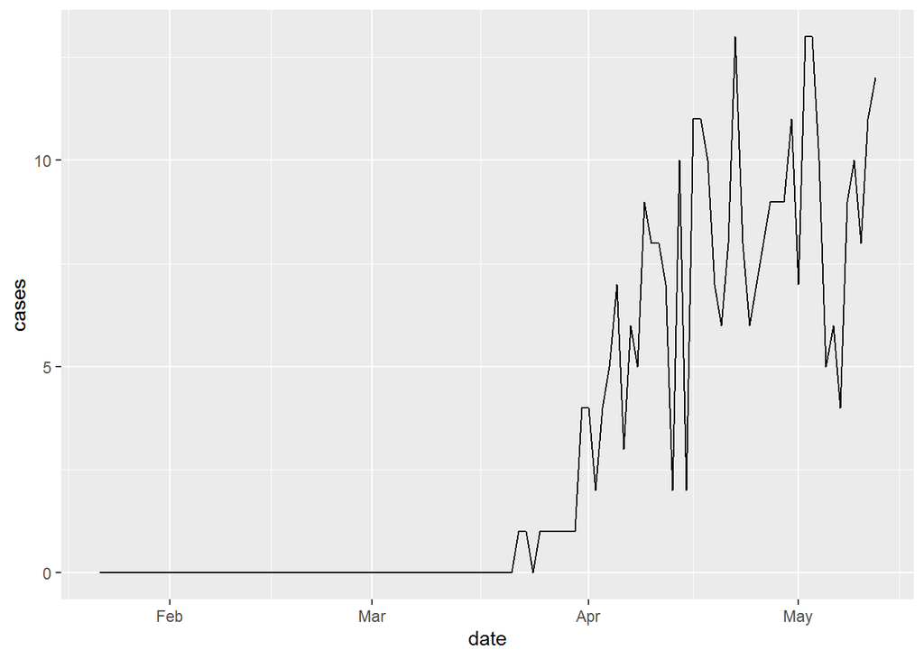

Figure 03- Chile: Daily Covid-19 Deaths

In Figure 03 we can see an increase of number of deaths until May 12th 2020.

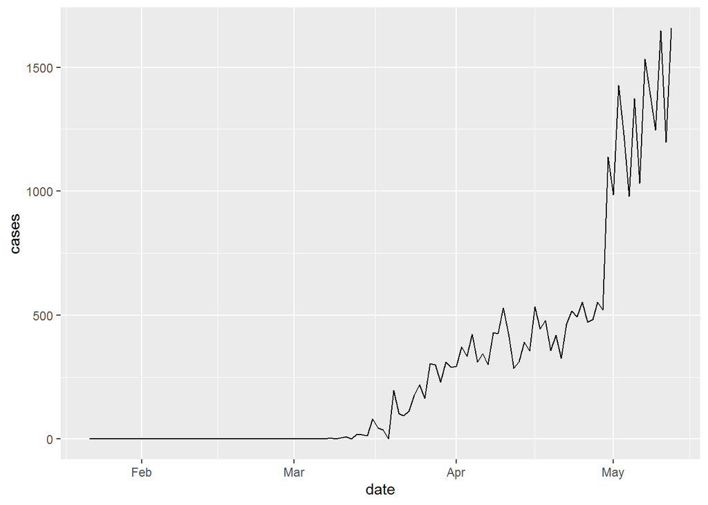

Figure 04- Chile: Daily Covid-19 Confirm Cases

In Figure 04 we can see a slow increase of confirm cases until end of April but a huge rise up of confirm cases at the beginning of May.

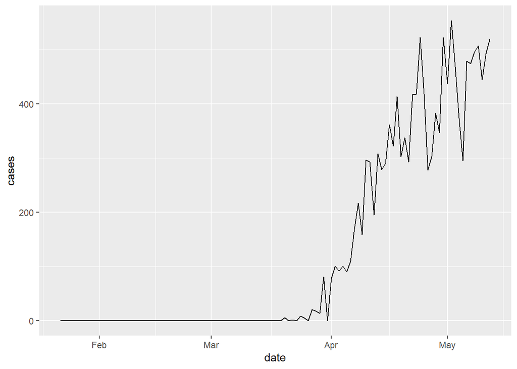

Figure 05- Chile: Daily Covid-19 Recoveries

In Figure 05 we can see the number of recovered patients also increased gradually.

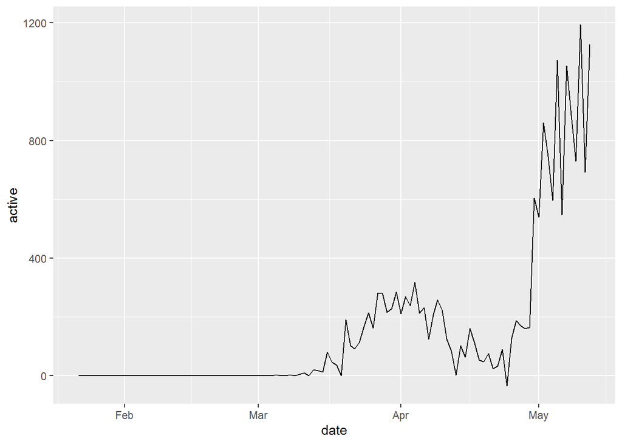

Figure 06- Chile: Daily Covid-19 Active Cases

We can clearly see in the Figure 06 that the active cases of COVID-19 in Chile is rised up highly in May.

### Comparison with Neighbouring Countries

Let us compare how the confirmed, death, recovered and active cases varies in Peru and Argentina with Chile as Peru and Argentina are the close neighbouring countries of Chile.

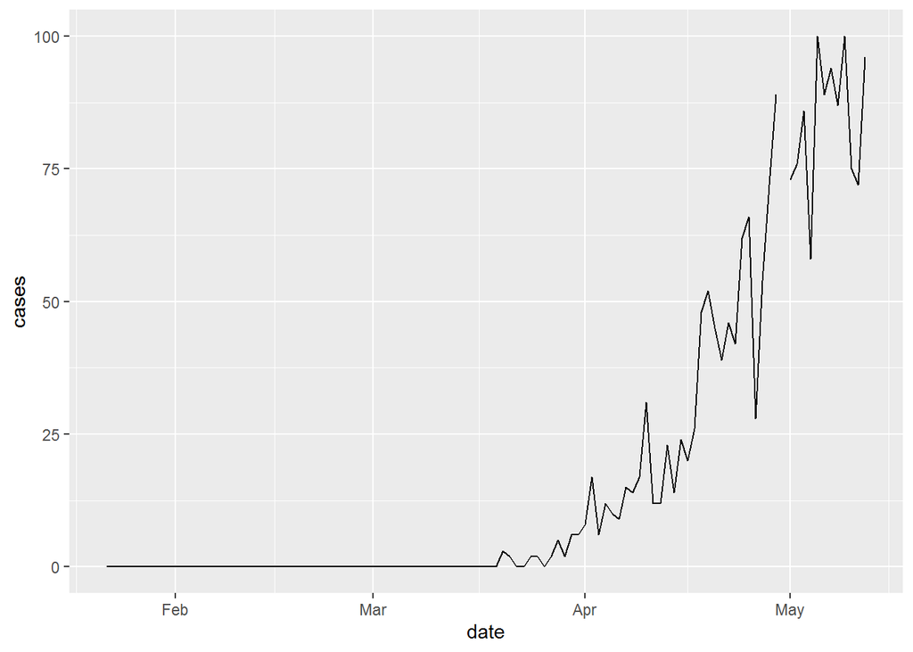

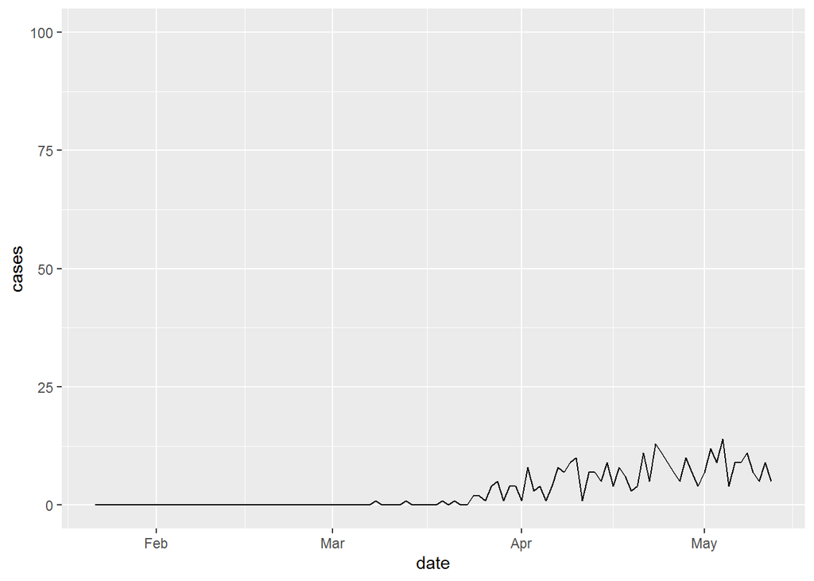

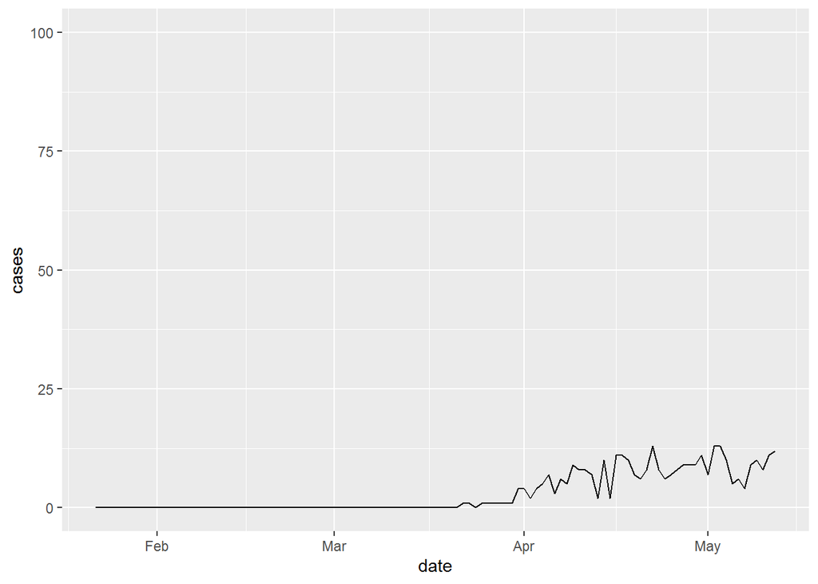

Figure 07- Peru, Argentina and Chile daily COVID-19 Deaths

Left side corner of the Figure 07 is the how the number of deaths due to COVID-19 in Peru varies daily. Then Argentina daily deaths and next Chile. Here we can see compared to other two countries Peru has the highest number of deaths repored detaily until May 12th and a slightly similar pattern in daily deaths in Argentina ana Chile.

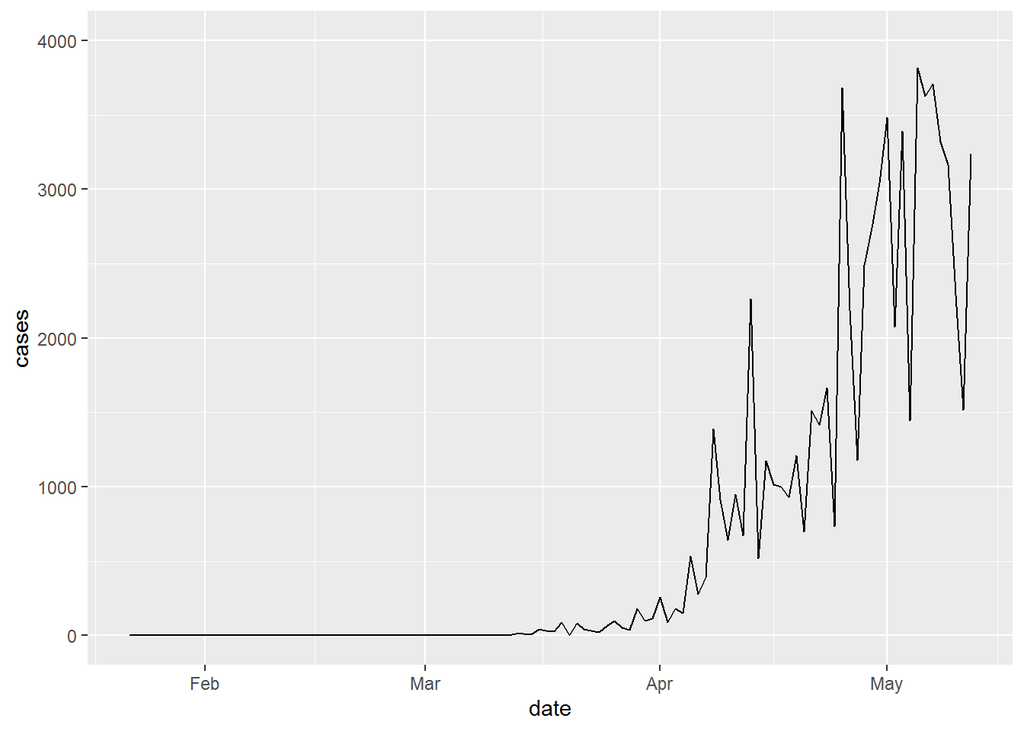

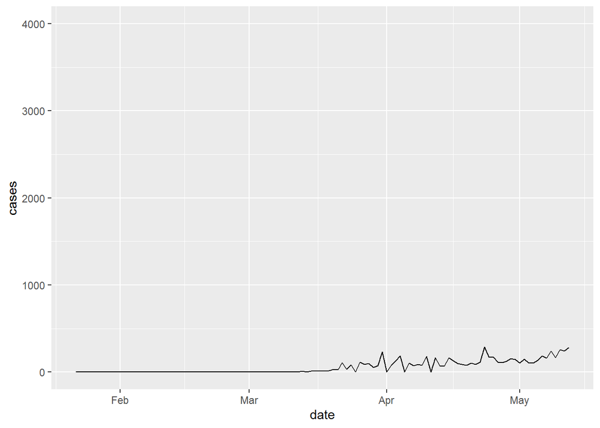

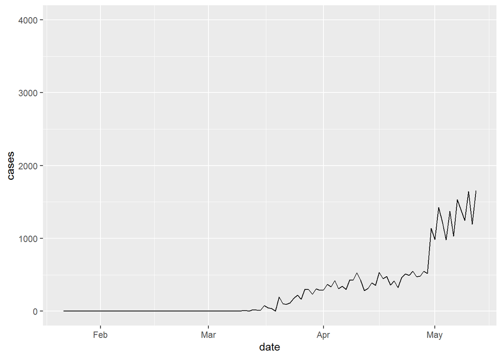

Figure 08- Peru, Argentina and Chile daily COVID-19 Confirm Cases

Left side corner of the Figure 08 is the how the number of confirmed cases of COVID-19 in Peru varies daily. Then Argentina daily confirmed cases and next Chile. chile got the highest number of confirmed cases at the beginning of April compared to Peru and Argentina. But the count rised up rapidly in Peru from the mid of April. Chile has a higher number of confirmed cases compared to Argentina but very low compared to Peru.

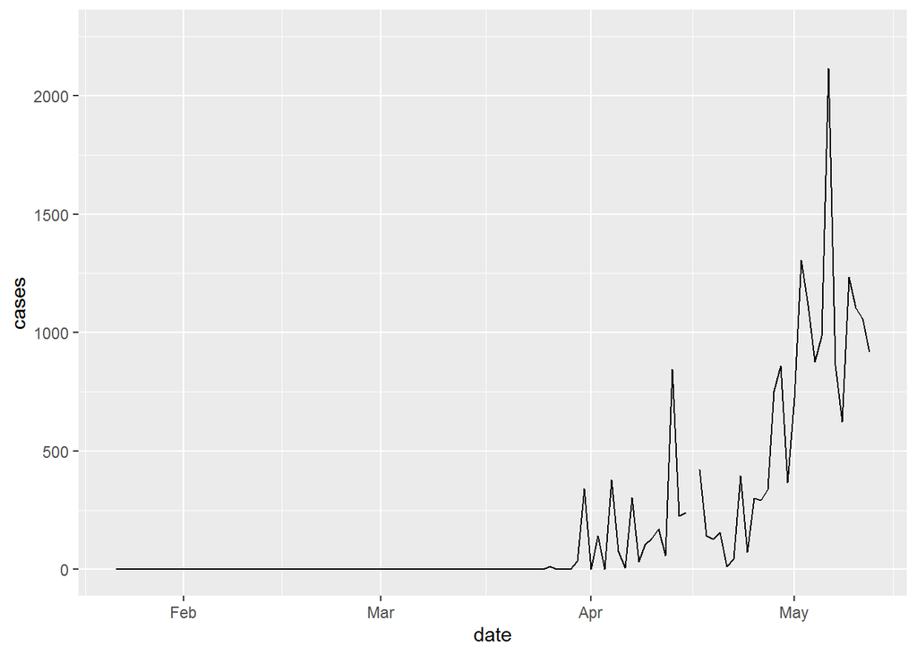

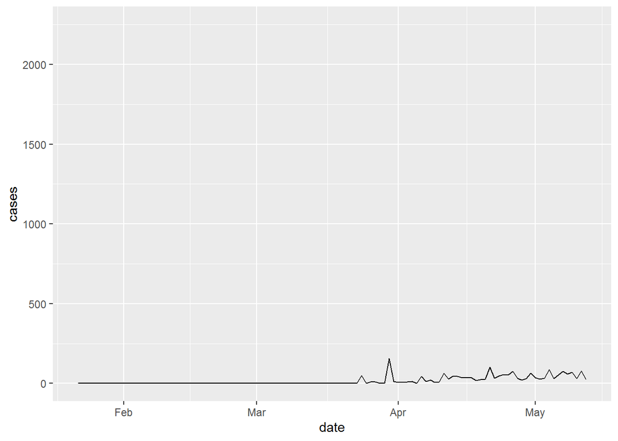

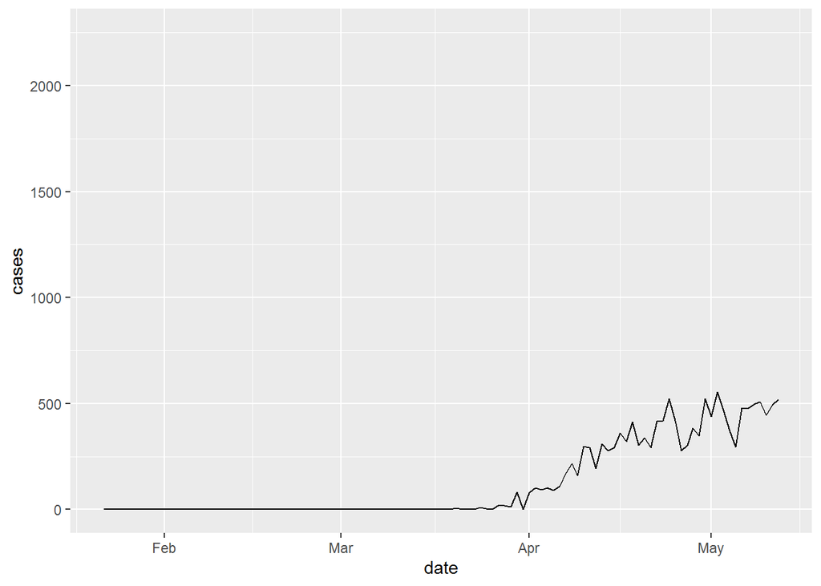

Figure 09- Peru, Argentina and Chile daily COVID-19 Recoveries

Left side corner of the Figure 09 is the how the number of recoveries of COVID-19 in Peru varies daily. Then Argentina daily recoveries and next Chile. Here also we can see the recoverd count is higher in Peru compared to other two countries. Chile aslo has a quite increasing pattern in the daily recovered counts.

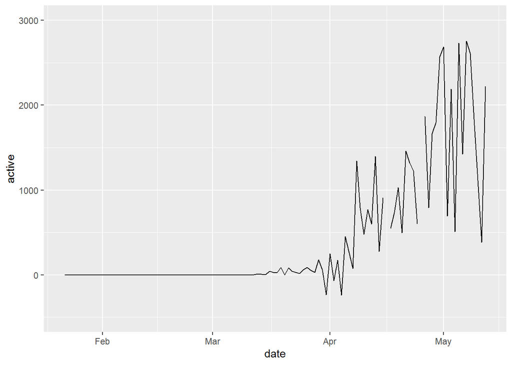

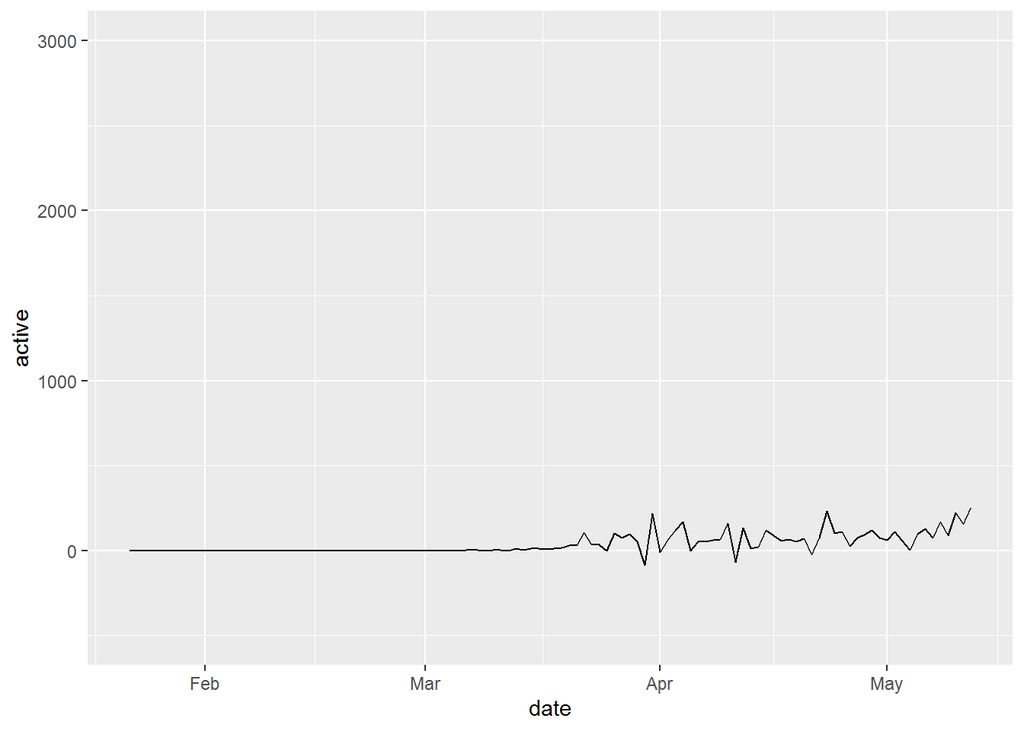

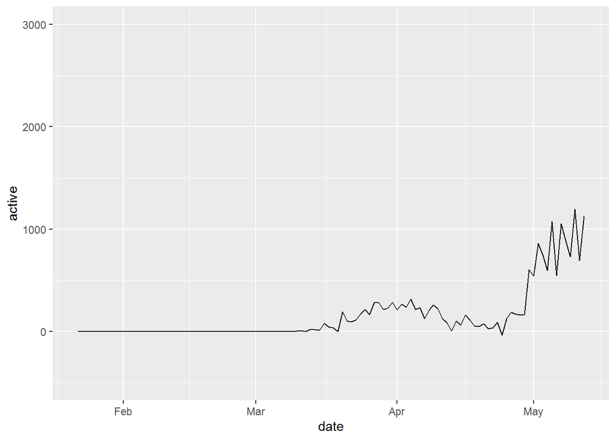

Figure 10- Peru, Argentina and Chile daily COVID-19 Active Cases

Left side corner of the Figure 10 is the how the number of active cases of COVID-19 in Peru varies daily. Then Argentina daily active cases and next Chile. Untill May 12th active cases are very high in Peru compared to Argentina and Chile. Chile repoted around 1000 active cases and it is very much high compared to the counts of active cases in Argentina.

# **Conclusion and Discussion**

1. Between 2020.01.22 to 2020.05.12 though the governent of Chile took actions to mitigate COVID-19 the confirmed cases rised up very quickly.
2. The reason for quick rise up of confirmed cases in May is still an unknown. I think the reason may be not to take quick actions when the first patient repored inside the country. The Chile government imposed the complete shutdown to the city Santiago only after May 16th. It is the fault ot the government.
3. Here we can see negative number of active cases in some days. That means these records may be not correct.
4. Compared to Peru withing this time interval Chile got very small number of confirmed cases and deaths. But from upto date records we can find now Chile is also same as high as Peru in confirm cases. So from only these limited records we cannot make a precise decision.
5. I think if the government of Chile took necessary actions from the very beginning these confirmed cases and death counts could be reduced.
6. Peru is a country with more that 31 million population and chile is a country with around 18 million population. So without taking the ratios for every variable using the absolute counts for comparison can make erroneos conclusions.

# **Reference**

COVID-19 pandemic in Chile- https://en.wikipedia.org/wiki/COVID-19_pandemic_in_Chile